# Histogram Exploration

Mariah Taylor and Yaskira Mota

February 5, 2017

### Part 1

We used fish length data that we had available  
Without changing any settings, this is how R represents the data by default  
There are 9 bins with a width of 50 mm

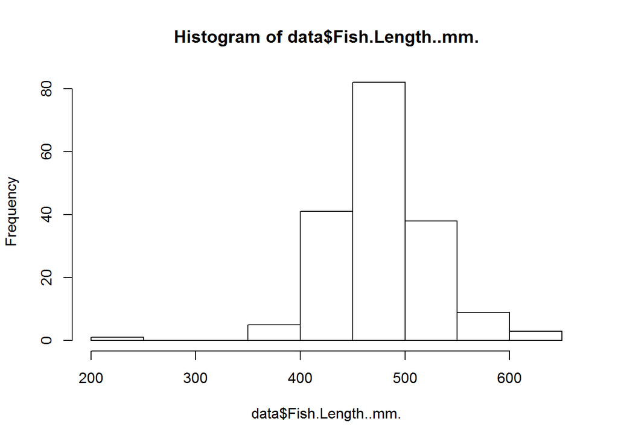

```r
knitr::opts_chunk$set(echo = TRUE)
data<-read.csv("LT_length_data.csv")
hist(data$Fish.Length..mm.)
```

### Part 2

We can have R Studio control the number of breaks in our code  
There can be fewer bins, but this is not the best way to represent our data because most of the data falls in the 400-600 mm category  
Here, there are 3 bins at 200 mm increments

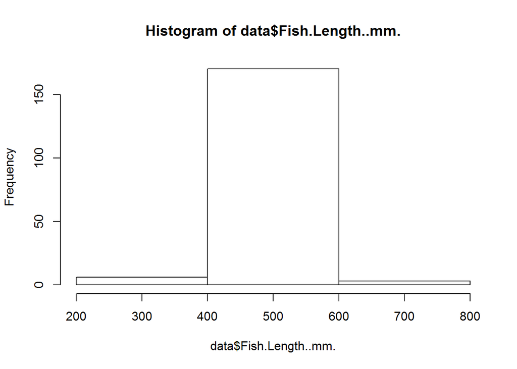

```r
hist(data$Fish.Length..mm., breaks=2)
```

### Part 3

We can also mannually control the number of breaks and bins in our code to better represent the data  
Here we use hashtags (#) to keep track of what our code is doing  
Using the Freedman-Diacobis rule, we found that ~20 bins of ~20 mm increments should be used

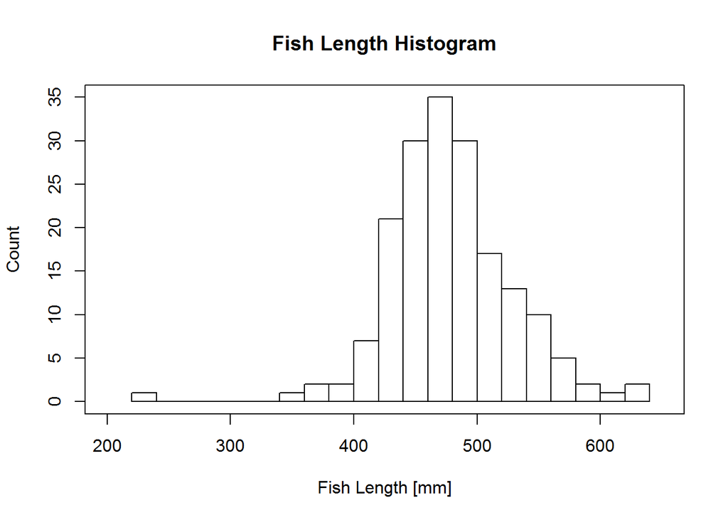

```r
#Using the Freedman-Diacobis rule we can find h (bin-width) and the number of bins
h<-2*IQR(data$Fish.Length..mm.)*(length(data$Fish.Length..mm.)^(-1/3))
#h=19.87
#Number of bins should be (max-min/h)
bins<-(max(data$Fish.Length..mm.)-min(data$Fish.Length..mm.))/h
#bins=20.58
hist(data$Fish.Length..mm., breaks=20,xlim=c(200,650), xlab="Fish Length [mm]", ylab="Count", main="Fish Length Histogram")
box()
```

### Conclusion

In conclusion, we believe using the Freedman-Diacobis rule helped us to identify the appropriate number of bins and the best way to look at the length-distribution of this fish population  
The first two histograms indicated most of the data was within the same length range while the final histogram provides a more precise estimate that may be important to understand